# CSE4CG-PyOpenGL-Lab-03

## 5143135: Computer Graphics @ ZJU School of Software Technology

## Lab 3: Bicubic Bezier Surfaces

Welcome to **5143135: Computer Graphics** !

After attending this lab class, you are expected to write Python programs with PyOpenGL that

- Displays 2D Bicubic Bezier Surfaces;
- Enables Keyboard Control.

Before we move on, please initialize your program as follows.

```python
from OpenGL.GL import *
from OpenGL.GLUT import *
from OpenGL.GLU import *
import math                                         # Support math operations
import numpy as np                                  # Support efficient vectors and matrices


def display():
    glClear(GL_COLOR_BUFFER_BIT | GL_DEPTH_BUFFER_BIT)
    glLoadIdentity()

    # add code to draw a surface

    glutSwapBuffers()


def idle():
    display()


def initRendering():
    glEnable(GL_DEPTH_TEST)
    # glEnable(GL_LIGHTING)
    # glEnable(GL_LIGHT0)


def reshape(w, h):
    glViewport(0, 0, w, h)

    glMatrixMode(GL_PROJECTION)
    glLoadIdentity()
    glOrtho(0.0, w, 0.0, h, 0.0, 1.0)

    glMatrixMode(GL_MODELVIEW)
    glLoadIdentity()


w, h = 500, 500
u, v = 100, 100

glutInit()
glutInitDisplayMode(GLUT_RGB |
                    GLUT_DOUBLE |
                    GLUT_DEPTH)

glutInitWindowSize(w, h)
glutInitWindowPosition(u, v)
glutCreateWindow("Lab 03")

initRendering()

glutReshapeFunc(reshape, w, h)
glutDisplayFunc(display)
#glutIdleFunc(idle)
glutMainLoop()
```

### Task 1: 2D Bicubic Bezier Surfaces

In Lecture 3, we discussed that turning the control points of a curve *P(u)* into the functions of another dimension *P_i(v)* results into a **2D** smooth surface. Such a method is called **Tensor Product Splines**. If *P(u)* and *P_i(v)* are all cubic Bezier curves, the surface created is known as a **Bicubic Bezier Surface**. The lecture mentioned that creating a bicubic Bezier surface requires

- **16** control points *P_i,j*; and
- **16** 2D basis functions *B_i,j(u,v)*, which is the multiplication of *B_i(u)* and *B_j(v)*.

Therefore, the first step in this task is to provide 16 control points with a NumPy array, like how we did in Lab 2. The display function can be re-written as follows.

```python
def display():
    control_points = np.array([ [150, 200],     # P 1,1
                                [200, 190],     # P 1,2
                                [250, 200],     # P 1,3
                                [300, 190],     # P 1,4
                                [140, 250],     # P 2,1
                                [210, 240],     # P 2,2
                                [260, 250],     # P 2,3
                                [290, 240],     # P 2,4
                                [150, 300],     # P 3,1
                                [200, 290],     # P 3,2
                                [250, 300],     # P 3,3
                                [300, 290],     # P 3,4
                                [140, 350],     # P 4,1
                                [210, 340],     # P 4,2
                                [260, 350],     # P 4,3
                                [290, 340]      # P 4,4
                                ])              # Control points as a NumPy array
    n = 10                                      # Number of intervals for discretizing u, v

    # Create a 4*4 matrix for each coordinate of the control points
    G_x = np.zeros((4, 4))
    G_y = np.zeros((4, 4))
    for i in range(4):
        for j in range(4):
            k = i * 4 + j
            G_x[i][j] = control_points[k][0]
            G_y[i][j] = control_points[k][1]

    glClear(GL_COLOR_BUFFER_BIT | GL_DEPTH_BUFFER_BIT)
    glLoadIdentity()

    # add code to draw a surface

    glutSwapBuffers()
```

In particular, the control points are stored in the NumPy array in a **by-row** order (i.e., the first four points are P_1,i, the ones in the first row). Note that following the creation of NumPy array, two **4x4** matrices are defined to contain the values regarding each coordinate of all control points. We accomplish the operation here because it can be done only **once** externally, instead of being repeated in the function that calculates *P(u,v)* (e.g., the *pBezierCurve* function in Lab 2).

Next, let's deal with the matrix multiplication. The curve function *P(u, v)* has been explained in the lecture according to the modified general spline formulation. Given the details, it is straightforward to define a corresponding function with Python as follows,

```python
def pBezierSurface(u, v, G_x, G_y):
    B = np.array([  [   1, -3,  3,  -1  ],
                    [   0,  3,  -6, 3   ],
                    [   0,  0,  3,  -3  ],
                    [   0,  0,  0,  1   ]   ])

    U = np.array([  [   1           ],
                    [   u           ],
                    [   u * u       ],
                    [   u * u * u   ]       ])

    V = np.array([  [   1           ],
                    [   v           ],
                    [   v * v       ],
                    [   v * v * v   ]       ])

    B_u = np.matmul(B, U).T
    B_v = np.matmul(B, V)

    p_x = np.matmul(B_u, np.matmul(G_x, B_v))
    p_y = np.matmul(B_u, np.matmul(G_y, B_v))

    p = np.concatenate((p_x[0], p_y[0]))

    return p
```

where *u* and *v* are the parameters of the surface (both range in [0, 1]), and *G_x* and *G_y* are the two matrices mentioned above. The returned *p* is an array storing the coordinates of the point on the surface at *(u, v)*. Note that the matrix multiplication always returns a matrix, even if it includes only one element (i.e., a **1x1** matrix). Therefore, we need to access the elements explicitly using index before concatenation.

We can generate points *P(u, v)* in the ranges of *u* and *v*, by calling the *pBezierSurface* function in a nested loop. All points are stored in a matrix-like list, as follows.

```python
# Create a matrix-like list of points P(u, v)
points = []
for i in range(n + 1):
    u = i / n
    points_by_u = []
    for j in range(n + 1):
        v = j / n
        p = pBezierSurface(u, v, G_x, G_y)
        points_by_u.append(p)

    points.append(points_by_u)
```

Now, we have to consider how to draw the surface onto the screen. In the lecture, we mentioned that a disadvantage of tensor product splines is the difficulty of rendering, and surfaces are usually converted to **triangles** (i.e., rendering primitives) for rendering. Thus, we can accomplish the drawing with *glBegin* and *glEnd*, especially using *GL_TRIANGLES*.

As we know, all generated points *P(u, v)* divides the entire surface into a cell grid, as illustrated in the figure below. Each cell, surronded by four points, is a quad.

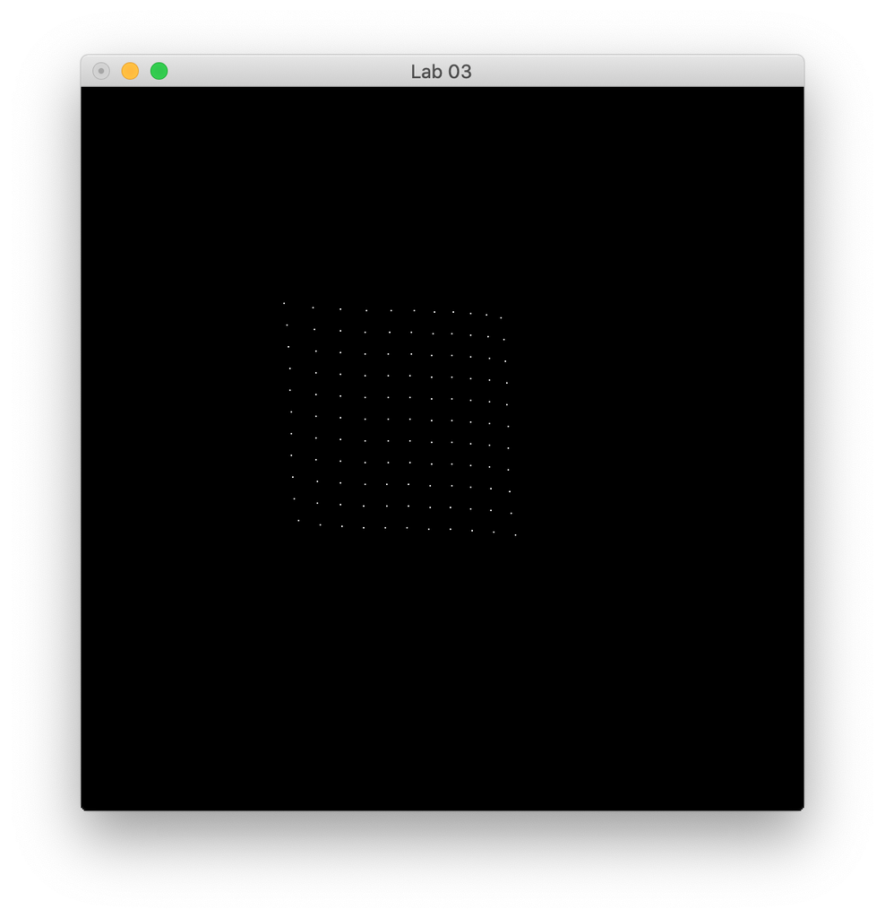

In particular, each cell is equivalent to two triangles sharing a boundary, as illustrated in the figure below.

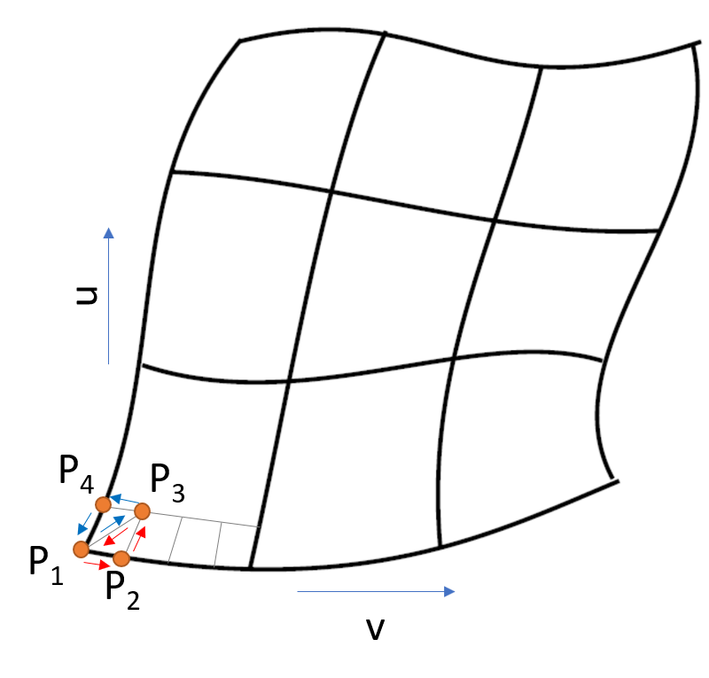

If we denote the lower-left point (known as an **anchor point**) as *P1* and, in the **anti-clockwise** direction, the others *P2, P3 and P4*, two triangles can be created as *P1->P3->P4* and *P1->P2->P3*. Note here we use the anti-clockwise direction in the triangle direction for it represents a **front face**.

According the order of points stored in the matrix-like list, we can implement the surface drawing as follows.

```python
# Draw the surface using triangles
glBegin(GL_TRIANGLES)
for i in range(n):
    for j in range(n):
        p1 = points[i][j]
        p2 = points[i][j + 1]
        p3 = points[i + 1][j + 1]
        p4 = points[i + 1][j]

        glVertex2fv(p1)
        glVertex2fv(p2)
        glVertex2fv(p3)
        glVertex2fv(p1)
        glVertex2fv(p3)
        glVertex2fv(p4)
glEnd()
```

Note the last point in each *row* and *column* of the matrix-like list cannot be used as an anchor point. We modify the *display* function as follows.

```python
from OpenGL.GL import *
from OpenGL.GLUT import *
from OpenGL.GLU import *

import math                                         # Support math operations
import numpy as np                                  # Support efficient vectors and matrices

def pBezierSurface(u, v, G_x, G_y):
    B = np.array([  [   1, -3,  3,  -1  ],
                    [   0,  3,  -6, 3   ],
                    [   0,  0,  3,  -3  ],
                    [   0,  0,  0,  1   ]   ])

    U = np.array([  [   1           ],
                    [   u           ],
                    [   u * u       ],
                    [   u * u * u   ]       ])

    V = np.array([  [   1           ],
                    [   v           ],
                    [   v * v       ],
                    [   v * v * v   ]       ])

    B_u = np.matmul(B, U).T
    B_v = np.matmul(B, V)

    p_x = np.matmul(B_u, np.matmul(G_x, B_v))
    p_y = np.matmul(B_u, np.matmul(G_y, B_v))

    return np.concatenate((p_x[0], p_y[0]))

def display():
    control_points = np.array([ [150, 200],     # P 1,1
                                [200, 190],     # P 1,2
                                [250, 200],     # P 1,3
                                [300, 190],     # P 1,4
                                [140, 250],     # P 2,1
                                [210, 240],     # P 2,2
                                [260, 250],     # P 2,3
                                [290, 240],     # P 2,4
                                [150, 300],     # P 3,1
                                [200, 290],     # P 3,2
                                [250, 300],     # P 3,3
                                [300, 290],     # P 3,4
                                [140, 350],     # P 4,1
                                [210, 340],     # P 4,2
                                [260, 350],     # P 4,3
                                [290, 340]      # P 4,4
                                ])              # Control points as a NumPy array
    n = 50                                      # Number of intervals for discretizing u, v

    # Create a 4*4 matrix for each coordinate of the control points
    G_x = np.zeros((4, 4))
    G_y = np.zeros((4, 4))
    for i in range(4):
        for j in range(4):
            k = i * 4 + j
            G_x[i][j] = control_points[k][0]
            G_y[i][j] = control_points[k][1]

    # Reset
    glClear(GL_COLOR_BUFFER_BIT | GL_DEPTH_BUFFER_BIT)
    glLoadIdentity()

    # Create a matrix-like list of points P(u, v)
    points = []
    for i in range(n + 1):
        u = i / n
        points_by_u = []
        for j in range(n + 1):
            v = j / n
            p = pBezierSurface(u, v, G_x, G_y)
            points_by_u.append(p)

        points.append(points_by_u)

    # Draw the surface using triangles
    glBegin(GL_TRIANGLES)
    for i in range(n):
        for j in range(n):
            p1 = points[i][j]
            p2 = points[i][j + 1]
            p3 = points[i + 1][j + 1]
            p4 = points[i + 1][j]
            glVertex2fv(p1)
            glVertex2fv(p2)
            glVertex2fv(p3)
            glVertex2fv(p1)
            glVertex2fv(p3)
            glVertex2fv(p4)
    glEnd()

    glutSwapBuffers()


def idle():
    display()


def initRendering():
    glEnable(GL_DEPTH_TEST)
    # glEnable(GL_LIGHTING)
    # glEnable(GL_LIGHT0)


def reshape(w, h):
    glViewport(0, 0, w, h)

    glMatrixMode(GL_PROJECTION)
    glLoadIdentity()
    glOrtho(0.0, w, 0.0, h, 0.0, 1.0)

    glMatrixMode(GL_MODELVIEW)
    glLoadIdentity()


w, h = 500, 500
u, v = 100, 100

glutInit()
glutInitDisplayMode(GLUT_RGB |
                    GLUT_DOUBLE |
                    GLUT_DEPTH)

glutInitWindowSize(w, h)
glutInitWindowPosition(u, v)
glutCreateWindow("Lab 03")

initRendering()

glutReshapeFunc(reshape, w, h)
glutDisplayFunc(display)
#glutIdleFunc(idle)
glutMainLoop()
```

Run the program and see if the output is the same to the following figure.

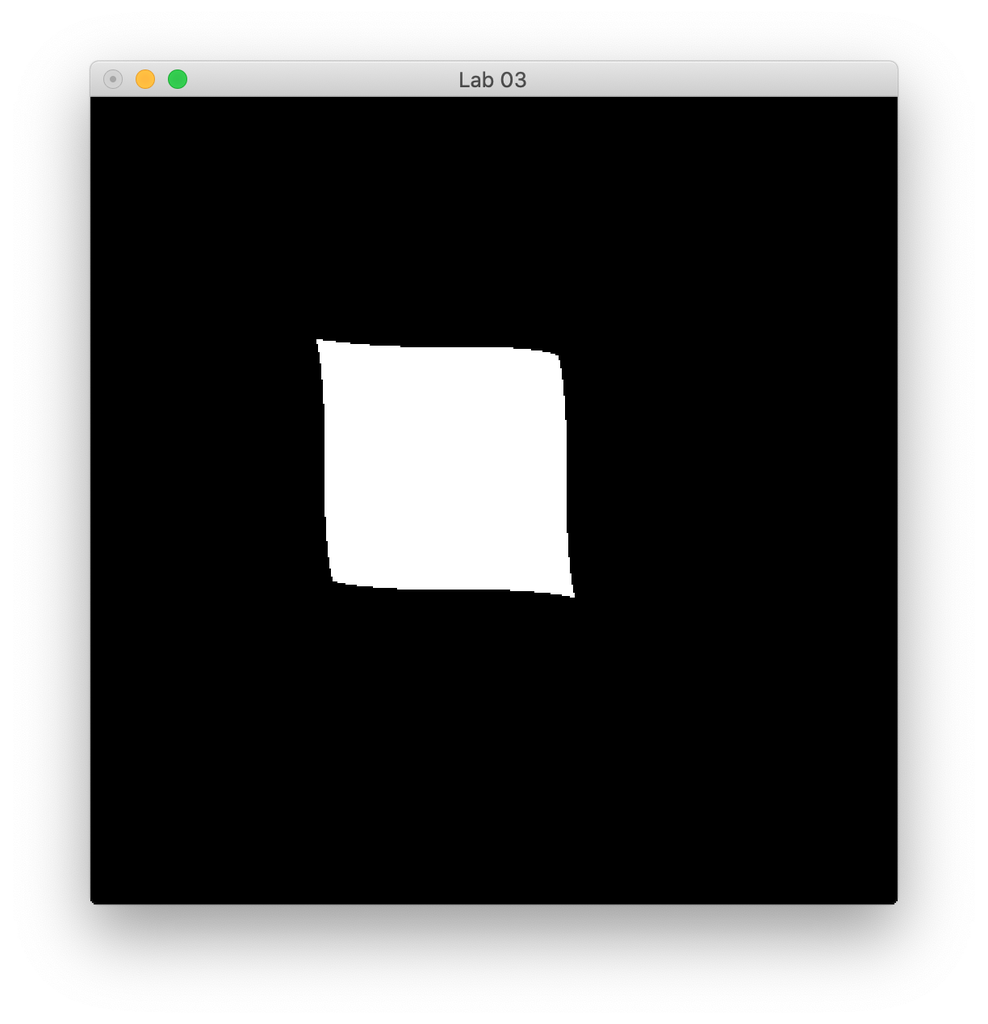

### Task 2: Keyboard Control

Most of CG applications enables us to interact with and control the displayed scenes or objects using various input devices, which include keyboards. In particular, when we press one or multiple keys, the corresponding command is called to take certain actions.

In OpenGL, we can activate keyboard control by registering a self-defined function to OpenGL using *glutKeyboardFunc*, which sets the keyboard callback for the current window. When a user types into the window, each key press generating an ASCII character will generate a keyboard callback. The **key** callback parameter is the generated ASCII character. The state of modifier keys such as Shift cannot be determined directly; their only effect will be on the returned ASCII data. The **x** and **y** callback parameters indicate the mouse location in window relative coordinates when the key was pressed. When a new window is created, no keyboard callback is initially registered, and ASCII key strokes in the window are ignored. Passing NULL to glutKeyboardFunc disables the generation of keyboard callbacks.

Suppose we would like the surface's color is changed to a **random** color when the key **C** is pressed. In Python, a native module **random** implements pseudo-random number generators for various distributions. The following code imports the module and prints a random float number in [0, 1] returned by a static function **random** of the module.

```python
import random

print(random.random())
```

Having random float numbers, we can create a random color by passing them to *glColor3f*. Thereafter, a function with three parameters, **key**, **x** and **y**, is defined to reach our goal, as follows.

```python
def pressKey(key, x, y):
    if key == b'c':
        glColor3f(random.random(), random.random(), random.random())
```

As explained, the **key** parameter refers to the key pressed, however, in *bytes*. Hence, when checking if it equals any character, don't forget to add a prefix *b* before the character (Note it is lower **c** here instead of upper **C**). You may figure out that the *pressKey* function changes the color's status randomly by calling *glColor3f*.

Then, we need to register the *pressKey* function to OpenGL in the program's main body, but before calling *glutMainLoop*, as follows.

```python
glutKeyboardFunc(pressKey)
```

Now, let's organize the program as follows and run it. Have a try what happens after pressing the key *C*.

```python
from OpenGL.GL import *
from OpenGL.GLUT import *
from OpenGL.GLU import *

import math                                         # Support math operations
import numpy as np                                  # Support efficient vectors and matrices
import random

def pBezierSurface(u, v, G_x, G_y):
    B = np.array([  [   1, -3,  3,  -1  ],
                    [   0,  3,  -6, 3   ],
                    [   0,  0,  3,  -3  ],
                    [   0,  0,  0,  1   ]   ])

    U = np.array([  [   1           ],
                    [   u           ],
                    [   u * u       ],
                    [   u * u * u   ]       ])

    V = np.array([  [   1           ],
                    [   v           ],
                    [   v * v       ],
                    [   v * v * v   ]       ])

    B_u = np.matmul(B, U).T
    B_v = np.matmul(B, V)

    p_x = np.matmul(B_u, np.matmul(G_x, B_v))
    p_y = np.matmul(B_u, np.matmul(G_y, B_v))

    return np.concatenate((p_x[0], p_y[0]))

def display():
    control_points = np.array([ [150, 200],     # P 1,1
                                [200, 190],     # P 1,2
                                [250, 200],     # P 1,3
                                [300, 190],     # P 1,4
                                [140, 250],     # P 2,1
                                [210, 240],     # P 2,2
                                [260, 250],     # P 2,3
                                [290, 240],     # P 2,4
                                [150, 300],     # P 3,1
                                [200, 290],     # P 3,2
                                [250, 300],     # P 3,3
                                [300, 290],     # P 3,4
                                [140, 350],     # P 4,1
                                [210, 340],     # P 4,2
                                [260, 350],     # P 4,3
                                [290, 340]      # P 4,4
                                ])              # Control points as a NumPy array
    n = 10                                      # Number of intervals for discretizing u, v

    # Create a 4*4 matrix for each coordinate of the control points
    G_x = np.zeros((4, 4))
    G_y = np.zeros((4, 4))
    for i in range(4):
        for j in range(4):
            k = i * 4 + j
            G_x[i][j] = control_points[k][0]
            G_y[i][j] = control_points[k][1]

    # Reset
    glClear(GL_COLOR_BUFFER_BIT | GL_DEPTH_BUFFER_BIT)
    glLoadIdentity()

    # Create a matrix-like list of points P(u, v)
    glBegin(GL_POINTS)
    points = []
    for i in range(n + 1):
        u = i / n
        points_by_u = []
        for j in range(n + 1):
            v = j / n
            p = pBezierSurface(u, v, G_x, G_y)
            points_by_u.append(p)
            glVertex2fv(p)

        points.append(points_by_u)
    glEnd()

    # Draw the surface using triangles
    glBegin(GL_TRIANGLES)
    for i in range(n):
        for j in range(n):
            p1 = points[i][j]
            p2 = points[i][j + 1]
            p3 = points[i + 1][j + 1]
            p4 = points[i + 1][j]
            glVertex2fv(p1)
            glVertex2fv(p2)
            glVertex2fv(p3)
            glVertex2fv(p1)
            glVertex2fv(p3)
            glVertex2fv(p4)
    glEnd()

    glutSwapBuffers()


def idle():
    display()


def initRendering():
    glEnable(GL_DEPTH_TEST)
    # glEnable(GL_LIGHTING)
    # glEnable(GL_LIGHT0)


def reshape(w, h):
    glViewport(0, 0, w, h)

    glMatrixMode(GL_PROJECTION)
    glLoadIdentity()
    glOrtho(0.0, w, 0.0, h, 0.0, 1.0)

    glMatrixMode(GL_MODELVIEW)
    glLoadIdentity()

def pressKey(key, x, y):
    if key == b'c':
        glColor3f(random.random(), random.random(), random.random())



w, h = 500, 500
u, v = 100, 100

glutInit()
glutInitDisplayMode(GLUT_RGB |
                    GLUT_DOUBLE |
                    GLUT_DEPTH)

glutInitWindowSize(w, h)
glutInitWindowPosition(u, v)
glutCreateWindow("Lab 03")

initRendering()

glutReshapeFunc(reshape, w, h)
glutDisplayFunc(display)
glutIdleFunc(idle)
glutKeyboardFunc(pressKey)
glutMainLoop()
```

### Questions

#### Q1: Write a Python program with PyOpenGL to modify Task 1, displaying the surface using quads.

#### Q2: Write a Python program with PyOpenGL to modify Task 1, displaying the surface's skeleton, as follows.

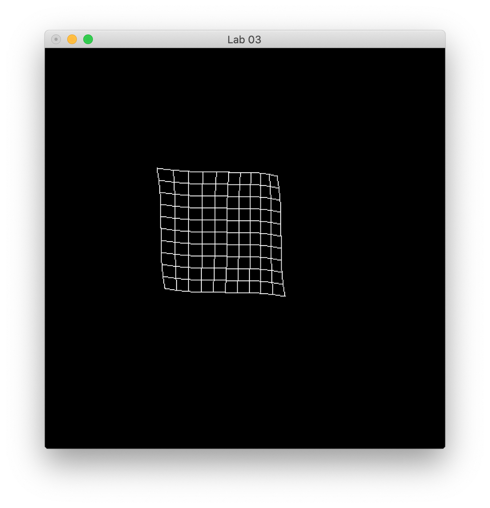

#### A sample solution is to be provided after the lab on the DingTalk group :)